# 1US0 TYR Ring_0_0.3_12_Density

10/41

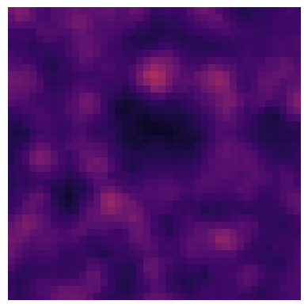

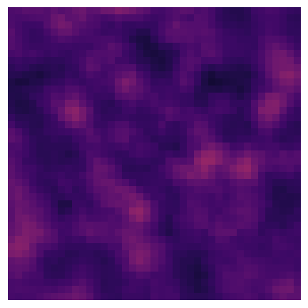

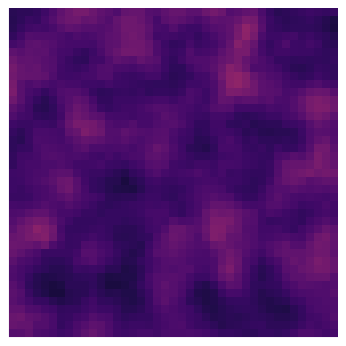

11/41

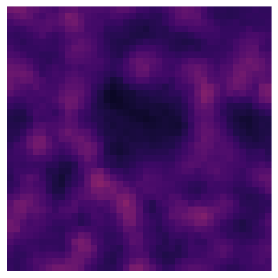

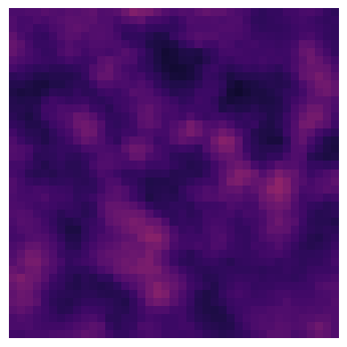

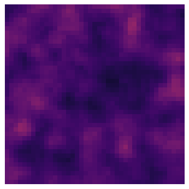

12/41

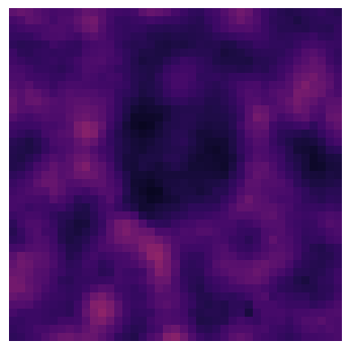

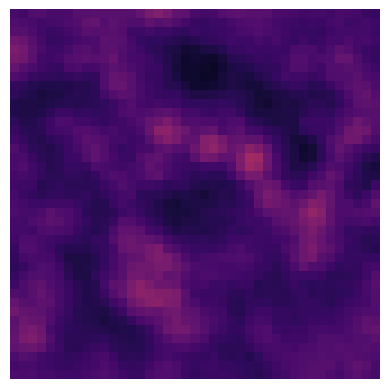

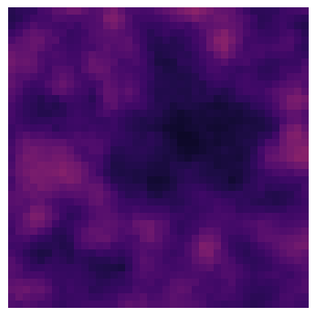

13/41

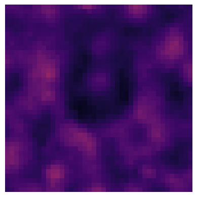

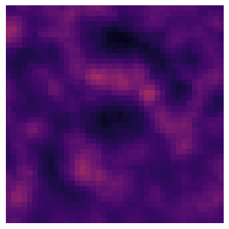

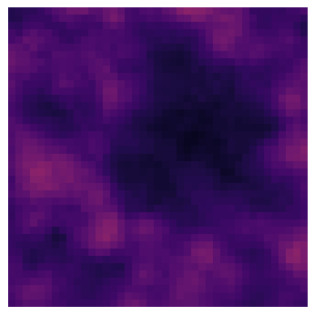

14/41

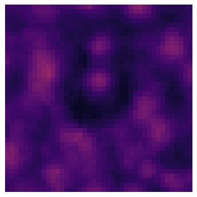

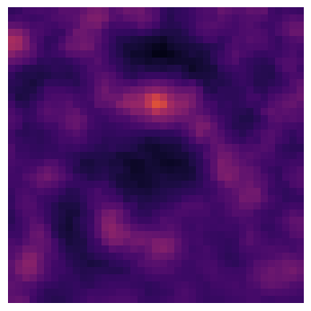

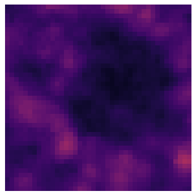

15/41

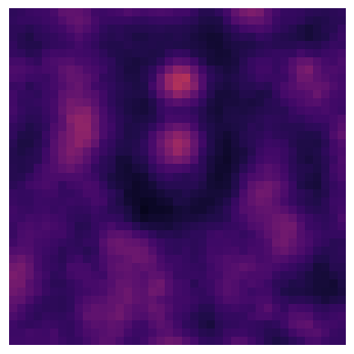

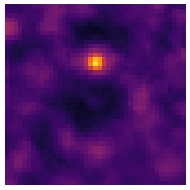

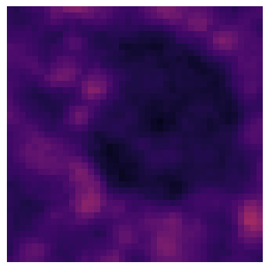

16/41

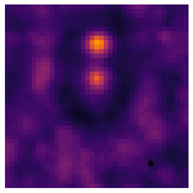

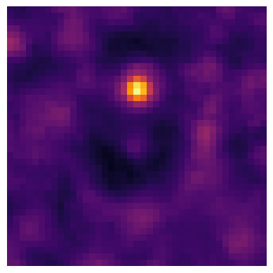

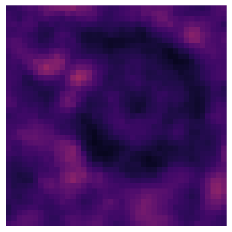

17/41

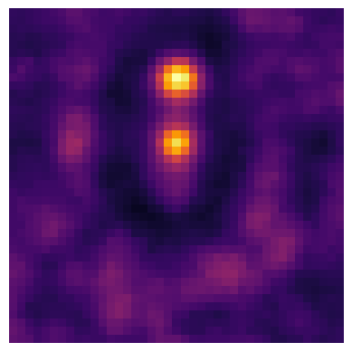

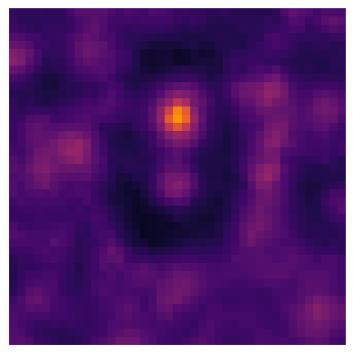

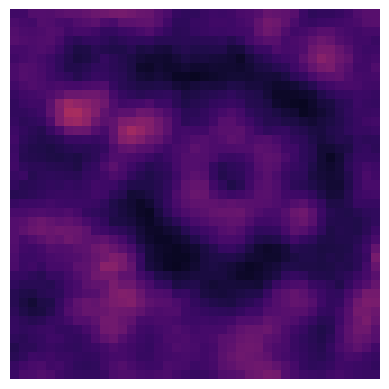

18/41